# Homework 5

Daniel Dulaney

```r
knitr::opts_chunk$set(message = FALSE, warning = FALSE)
```

```r
library(tidyverse)
library(here)
library(ggeasy)
```

## 1.

```r
# read data in and convert 3 columns to type factor
crabs <-
  read.table(here("hw05_summarizing-data", "crabs.txt"),
           header = TRUE) %>%
  as_tibble() %>%
  mutate_at(vars(color, spine, y), as.factor)

# relabel the 3 factors
levels(crabs$color) <- c("light", "medium", "dark", "darker")
levels(crabs$spine) <- c("Both Good", "One Worn/Broken", "Both Worn/Broken")
levels(crabs$y) <- c("No Sattelite", "At least 1 Sattelite")

print(crabs)
```

```
## # A tibble: 173 x 6
##    color  spine            width satell weight y
##    <fct>  <fct>            <dbl>  <int>  <int> <fct>
##  1 medium Both Worn/Broken  28.3      8   3050 At least 1 Sattelite
##  2 dark   Both Worn/Broken  22.5      0   1550 No Sattelite
##  3 light  Both Good         26        9   2300 At least 1 Sattelite
##  4 dark   Both Worn/Broken  24.8      0   2100 No Sattelite
##  5 dark   Both Worn/Broken  26        4   2600 At least 1 Sattelite
##  6 medium Both Worn/Broken  23.8      0   2100 No Sattelite
##  7 light  Both Good         26.5      0   2350 No Sattelite
##  8 dark   One Worn/Broken   24.7      0   1900 No Sattelite
##  9 medium Both Good         23.7      0   1950 No Sattelite
## 10 dark   Both Worn/Broken  25.6      0   2150 No Sattelite
## # ... with 163 more rows
```

## 2.

```r
table(crabs$satell, crabs$spine)
```

```
##
##      Both Good One Worn/Broken Both Worn/Broken
##   0         11               8               43
##   1          3               0               13
##   2          1               0                8
##   3          2               2               15
##   4          4               3               12
##   5          7               0                8
##   6          3               2                8
##   7          1               0                3
##   8          2               0                4
##   9          2               0                1
##   10         0               0                3
##   11         0               0                1
##   12         0               0                1
##   14         1               0                0
##   15         0               0                1
```

The number in the very top-left tells us that for female horshoe crabs with no sattelite males, 11 (out of 62) have two good spines. The number in the very bottom-right tells us that the only crab with 15 sattelites has two broken or worn spines.

## 3.

```r
tab <- table(crabs$color, crabs$spine, crabs$satell)
tab
```

```
## , ,  = 0
##
##
##          Both Good One Worn/Broken Both Worn/Broken
##   light          2               0                1
##   medium         8               5               13
##   dark           0               2               16
##   darker         1               1               13
##
## , ,  = 1
##
##
##          Both Good One Worn/Broken Both Worn/Broken
##   light          0               0                0
##   medium         3               0                8
##   dark           0               0                5
##   darker         0               0                0
##
## , ,  = 2
##
##
##          Both Good One Worn/Broken Both Worn/Broken
##   light          1               0                0
##   medium         0               0                6
##   dark           0               0                2
##   darker         0               0                0
##
## , ,  = 3
##
##
##          Both Good One Worn/Broken Both Worn/Broken
##   light          0               1                0
##   medium         1               0                8
##   dark           1               1                5
##   darker         0               0                2
##
## , ,  = 4
##
##
##          Both Good One Worn/Broken Both Worn/Broken
```

[output cut: 79 more lines]

```
##
##          Both Good One Worn/Broken Both Worn/Broken
##   light          0               0                0
##   medium         1               0                0
##   dark           0               0                0
##   darker         0               0                0
##
## , ,  = 15
##
##
##          Both Good One Worn/Broken Both Worn/Broken
##   light          0               0                0
##   medium         0               0                1
##   dark           0               0                0
##   darker         0               0                0
```

```r
# since "darker" is the 3rd level
tab[3, , ]
```

```
##
##                     0  1  2  3  4  5  6  7  8  9 10 11 12 14 15
##   Both Good         0  0  0  1  1  0  0  0  0  1  0  0  0  0  0
##   One Worn/Broken   2  0  0  1  1  0  0  0  0  0  0  0  0  0  0
##   Both Worn/Broken 16  5  2  5  3  2  2  1  0  0  1  0  0  0  0
```

The number in the very top-left tells us that there are no dark-colored crabs with 0 sattelite males and spines that are both good.

## 4.

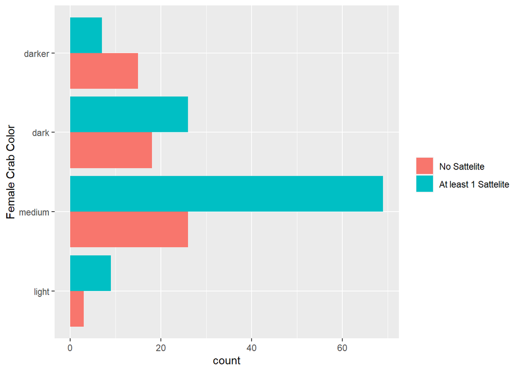

```r
crabs %>%
  ggplot(aes(color, fill = as.factor(y))) +
  geom_bar(position = "dodge") +
  coord_flip() +
  ggeasy::easy_remove_legend_title() +
  labs(x = "Female Crab Color")
```

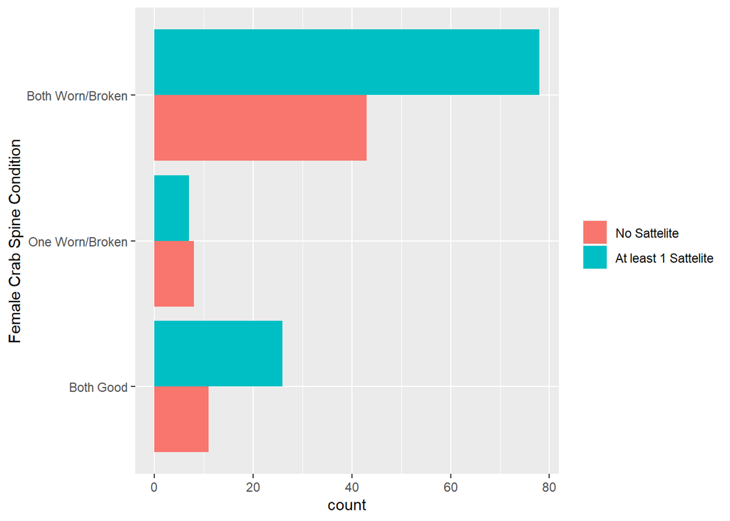

```r
crabs %>%
  ggplot(aes(spine, fill = as.factor(y))) +
  geom_bar(position = "dodge") +
  coord_flip() +
  ggeasy::easy_remove_legend_title() +
  labs(x = "Female Crab Spine Condition")
```

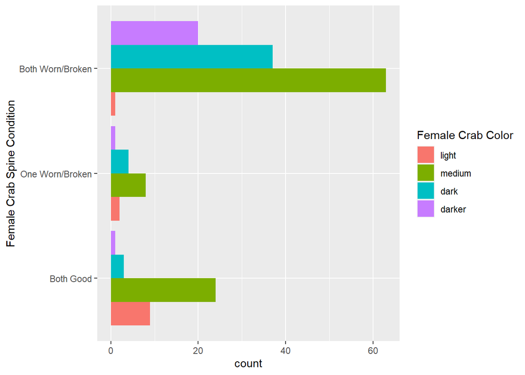

```r
crabs %>%
  ggplot(aes(spine, fill = as.factor(color))) +
  geom_bar(position = "dodge") +
  coord_flip() +
  ggeasy::easy_add_legend_title("Female Crab Color") +
  labs(x = "Female Crab Spine Condition")
```

Male crabs seem to like females who are medium-colored, as well as those with two good spines.

## 5.

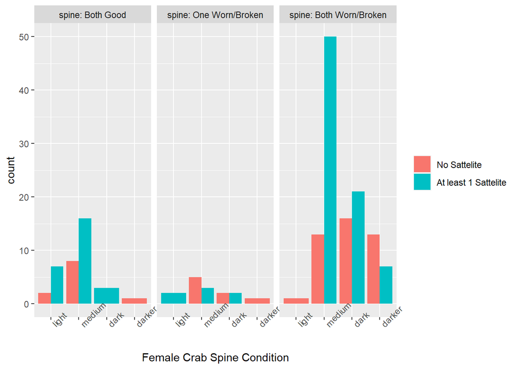

```r
crabs %>%
  mutate(spine = str_c("spine: ", spine),
         spine = fct_relevel(spine, c("spine: Both Good",
                                      "spine: One Worn/Broken",
                                      "spine: Both Worn/Broken"))) %>%
  ggplot(aes(color, fill = as.factor(y))) +
  geom_bar(position = "dodge") +
  facet_wrap(~spine) +
  ggeasy::easy_rotate_x_labels(angle = 45) +
  ggeasy::easy_remove_legend_title() +
  labs(x = "Female Crab Spine Condition")
```

There are relatively more sattelite-less female crabs among those with one or more broken spines.

## 6.

```r
crabs %>%
  group_by(color, y) %>%
  summarise(Avg = mean(weight),
            Sd = sd(weight),
            Median = median(weight),
            IQR = IQR(weight))
```

```
## # A tibble: 8 x 6
## # Groups:   color [4]
##   color  y                      Avg    Sd Median   IQR
##   <fct>  <fct>                <dbl> <dbl>  <dbl> <dbl>
## 1 light  No Sattelite         2525   152.   2600  138.
## 2 light  At least 1 Sattelite 2664.  442.   2700  650
## 3 medium No Sattelite         2242.  482.   2200  512.
## 4 medium At least 1 Sattelite 2649.  615.   2700  800
## 5 dark   No Sattelite         1907.  348.   1900  462.
## 6 dark   At least 1 Sattelite 2571.  495.   2575  719.
## 7 darker No Sattelite         2162.  436.   2150  650
## 8 darker At least 1 Sattelite 2200   523.   2100  200
```

The first row gives us the average, standard deviation, median, and (3rd quartile - 1st quartile) weight for all light-colored crabs with no sattelite males.

## 7.

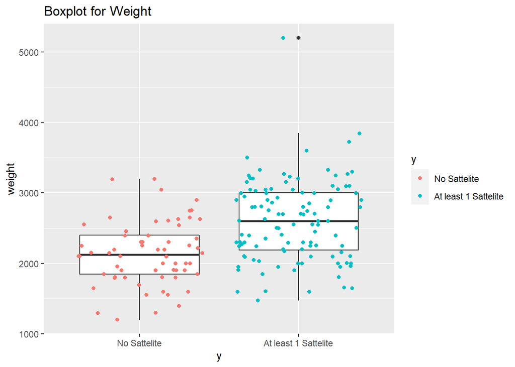

```r
crabs %>%
  ggplot(aes(y, weight)) +
  geom_boxplot() +
  geom_point(aes(color = y), position = "jitter") +
  labs(title = "Boxplot for Weight")
```

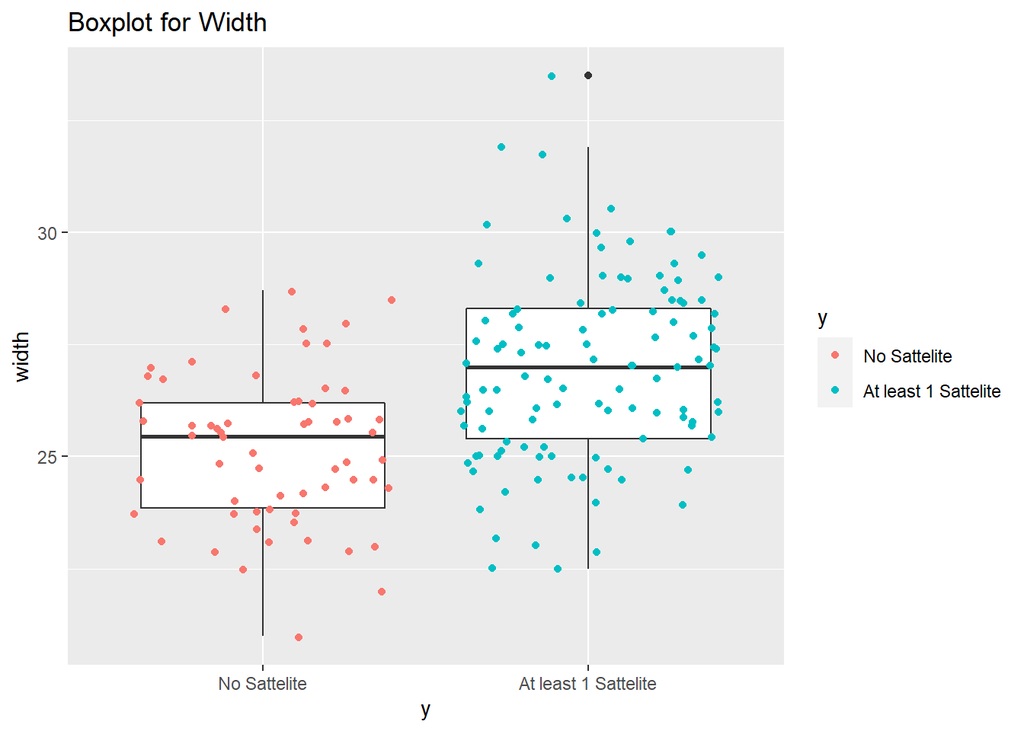

```r
crabs %>%
  ggplot(aes(y, width)) +
  geom_boxplot() +
  geom_point(aes(color = y), position = "jitter") +
  labs(title = "Boxplot for Width")
```

Female crabs with greater weight and width usually have more sattelites.

## 8.

```r
cor(crabs$weight, crabs$width)
```

```
## [1] 0.8868715
```

The correlation between weight and width is r = 0.89

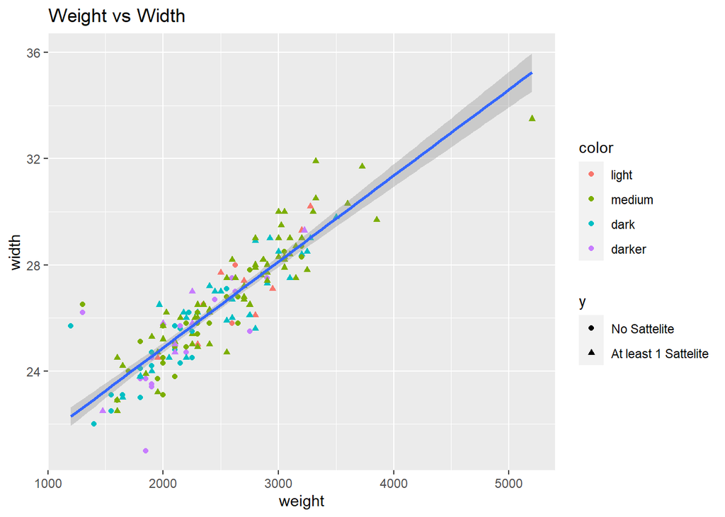

```r
crabs %>%
  ggplot(aes(weight, width)) +
  geom_point(aes(color = color, shape = y)) +
  geom_smooth(method = "lm") +
  labs(title = "Weight vs Width")
```

Weight and width are extremely highly correlated in the positive direction.